# NYPD Shooting Data

JamesYildiz

June 8, 2021

> This report analyzes the shooting incidents data from years 2006 through 2020 in New York City boroughs.

## Importing Data

```r
nypd <- "https://data.cityofnewyork.us/api/views/833y-fsy8/rows.csv"
nypd_data <- read.csv(nypd)
colnames(nypd_data)
```

```
##  [1] "INCIDENT_KEY"            "OCCUR_DATE"
##  [3] "OCCUR_TIME"              "BORO"
##  [5] "PRECINCT"                "JURISDICTION_CODE"
##  [7] "LOCATION_DESC"           "STATISTICAL_MURDER_FLAG"
##  [9] "PERP_AGE_GROUP"          "PERP_SEX"
## [11] "PERP_RACE"               "VIC_AGE_GROUP"
## [13] "VIC_SEX"                 "VIC_RACE"
## [15] "X_COORD_CD"              "Y_COORD_CD"
## [17] "Latitude"                "Longitude"
## [19] "Lon_Lat"
```

```r
summary(nypd_data)
```

```
##   INCIDENT_KEY        OCCUR_DATE         OCCUR_TIME            BORO
##  Min.   :  9953245   Length:23568       Length:23568       Length:23568
##  1st Qu.: 55317014   Class :character   Class :character   Class :character
##  Median : 83365370   Mode  :character   Mode  :character   Mode  :character
##  Mean   :102218616
##  3rd Qu.:150772442
##  Max.   :222473262
##
##     PRECINCT      JURISDICTION_CODE LOCATION_DESC      STATISTICAL_MURDER_FLAG
##  Min.   :  1.00   Min.   :0.0000    Length:23568       Length:23568
##  1st Qu.: 44.00   1st Qu.:0.0000    Class :character   Class :character
##  Median : 69.00   Median :0.0000    Mode  :character   Mode  :character
##  Mean   : 66.21   Mean   :0.3323
##  3rd Qu.: 81.00   3rd Qu.:0.0000
##  Max.   :123.00   Max.   :2.0000
##                   NA's   :2
##  PERP_AGE_GROUP       PERP_SEX          PERP_RACE         VIC_AGE_GROUP
##  Length:23568       Length:23568       Length:23568       Length:23568
##  Class :character   Class :character   Class :character   Class :character
##  Mode  :character   Mode  :character   Mode  :character   Mode  :character
##
##
##
##
##    VIC_SEX            VIC_RACE          X_COORD_CD         Y_COORD_CD
##  Length:23568       Length:23568       Length:23568       Length:23568
##  Class :character   Class :character   Class :character   Class :character
##  Mode  :character   Mode  :character   Mode  :character   Mode  :character
##
##
##
##
##     Latitude       Longitude        Lon_Lat
##  Min.   :40.51   Min.   :-74.25   Length:23568
##  1st Qu.:40.67   1st Qu.:-73.94   Class :character
##  Median :40.70   Median :-73.92   Mode  :character
##  Mean   :40.74   Mean   :-73.91
##  3rd Qu.:40.82   3rd Qu.:-73.88
##  Max.   :40.91   Max.   :-73.70
##
```

## Importing Libraries

> The following libraries will be needed for the cleaning and analysis of the data.

```r
library(lubridate)
library(tidyverse)
library(ggplot2)
library(tidyr)
```

## Data cleaning

> I will remove the columns I won’t need in the analysis.

```r
#Removing columns

nypd_data <- nypd_data %>% select(-c(PRECINCT, JURISDICTION_CODE, X_COORD_CD, Y_COORD_CD, Latitude, Longitude, Lon_Lat, INCIDENT_KEY, OCCUR_TIME, LOCATION_DESC, PERP_AGE_GROUP, PERP_SEX, PERP_RACE, VIC_AGE_GROUP, VIC_SEX, VIC_RACE))

colnames(nypd_data)
```

```
## [1] "OCCUR_DATE"              "BORO"
## [3] "STATISTICAL_MURDER_FLAG"
```

```r
#Convert date column to proper date format

nypd_data <- mutate(nypd_data, OCCUR_DATE = mdy(OCCUR_DATE))
```

> Total number of shootings per borough,

```r
boro_totals <- table(nypd_data$BORO)
boro_totals <- as.data.frame(boro_totals) %>% rename(Borough = Var1, Frequency = Freq)
boro_totals
```

```
##         Borough Frequency
## 1         BRONX      6700
## 2      BROOKLYN      9722
## 3     MANHATTAN      2921
## 4        QUEENS      3527
## 5 STATEN ISLAND       698
```

> The total population of each borough and shootings per 1,000 people

```r
borough_population = c(1418000, 2560000, 1629000, 2254000, 476000)


boro_totals <- boro_totals %>%
    mutate(Population = borough_population)


Per_kcapita = round(((boro_totals$Frequency/boro_totals$Population) * 1000),2)

boro_totals <- boro_totals %>%
    mutate(Per_kcapita = Per_kcapita)

boro_totals
```

```
##         Borough Frequency Population Per_kcapita
## 1         BRONX      6700    1418000        4.72
## 2      BROOKLYN      9722    2560000        3.80
## 3     MANHATTAN      2921    1629000        1.79
## 4        QUEENS      3527    2254000        1.56
## 5 STATEN ISLAND       698     476000        1.47
```

##### >The data shows that percapita shooting is the highest in Bronx. Also, while Queens seems to have about five times higher number of shootings than Staten Island, the per capita shooting is about the same for both boroughs.

> The histogram of the shootings per 1000 people by borough can be visualized as the following.

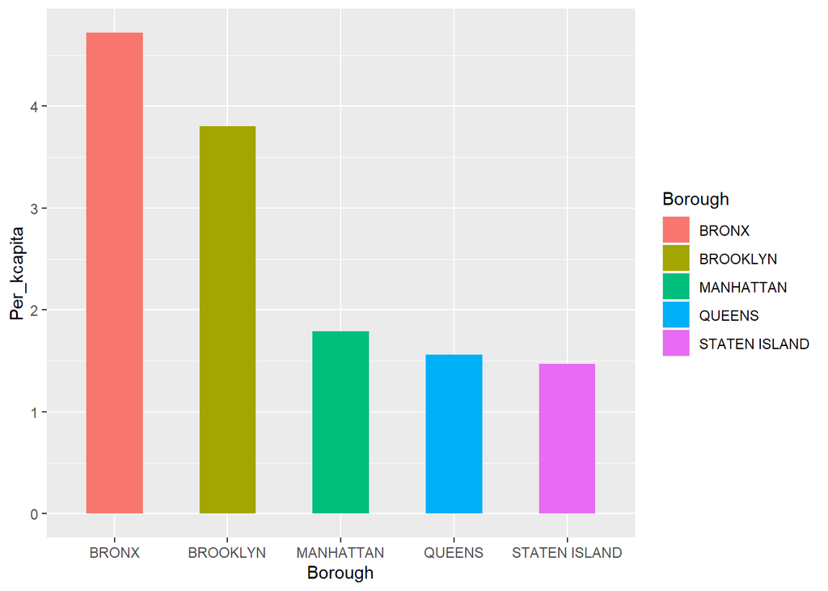

```r
ggplot(boro_totals, aes(x=Borough, y=Per_kcapita, fill = Borough)) + geom_col(width=0.5)
```

> Then, find the shootings in Bronx (borough with highest per capita shooting) by each month of the year.

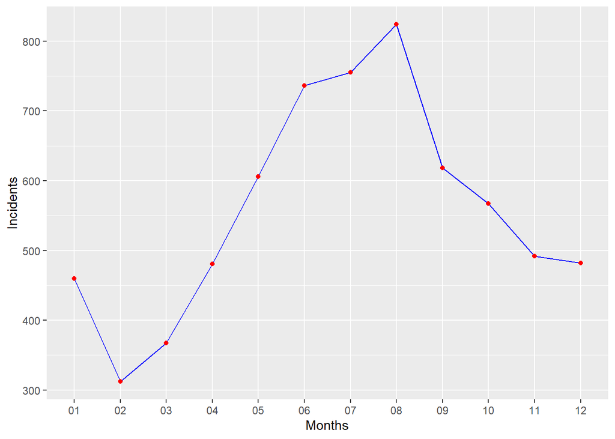

```r
BR <-subset(nypd_data, BORO=='BRONX', select=c(BORO, OCCUR_DATE))

BR$month <- substr(BR$OCCUR_DATE,6,7)

BR <- subset(BR, select = -c(OCCUR_DATE))

BRONX <- table(BR$month)
BRONX <- as.data.frame(BRONX)

colnames(BRONX)[colnames(BRONX) == "Var1"] <- "Months"
colnames(BRONX)[colnames(BRONX) == "Freq"] <- "Incidents"


ggplot(data=BRONX, aes(x=Months, y=Incidents, group = 1)) +
  geom_line(colour = "Blue") +
  geom_point(colour = "red")
```

> Let’s plot the number of incidents per month for Brooklyn.

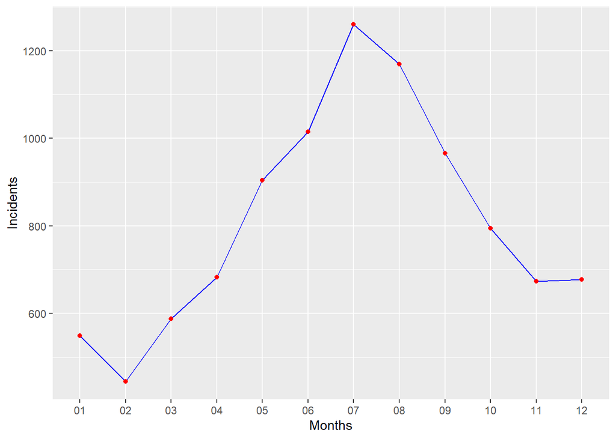

```r
BRLYN <-subset(nypd_data, BORO=='BROOKLYN', select=c(BORO, OCCUR_DATE))

BRLYN$month <- substr(BRLYN$OCCUR_DATE,6,7)

BRLYN <- subset(BRLYN, select = -c(OCCUR_DATE))

BROOKLYN <- table(BRLYN$month)
BROOKLYN <- as.data.frame(BROOKLYN)

colnames(BROOKLYN)[colnames(BROOKLYN) == "Var1"] <- "Months"
colnames(BROOKLYN)[colnames(BROOKLYN) == "Freq"] <- "Incidents"


ggplot(data=BROOKLYN, aes(x=Months, y=Incidents, group = 1)) +
  geom_line(colour = "Blue") +
  geom_point(colour = "red")
```

## Bias Analysis

In boroughs with heavy gang activities, many shooting shooting activities may not get reported to the police. This may add bias to the number from these boroughs.

On a personal level, I do not see any sources of bias on this data set. However, the selection of cities that I plan to extend this study may be affected by my personal connection to the cities. The cities that I know well may produce a more detailed report which will add bias to NYC data as it will not be as detailed and accurate on a comparative basis.

## Model, conclusion and the next steps.

As it can be seen on the plots, There is a significant increase in the shooting cases during the summer months. This may be due to increased social interactions among people during these months. I would like to analyze similar data sets from Los Angeles CA, Houston TX, and Orlando FL where the seasonal effects on social interactions are considerably less than that of NYC. Also, based on these two boroughs there is a predictive ratio between summer peak number and the months of November and December. The summer peak to holiday-season incidents ratio is around 1.7:1.0.

Another addition to this project would be to analyze smaller zones in each borough using the map coordinates and investigate the effect of the shooting incidents on property prices and school districts